# Seguimiento 3 - Notebook

# Seguimiento 3

## Introducción

En esta sesión hemos trabajado en distintos frentes simultáneamente tales como:

- Ampliación de preprocesamiento de datos.
- Ampliación de la parte de aprendizaje supervisado.
- Comienzo de la parte de aprendizaje no supervisado.

Antes de comenzar, necesitaremos definir ciertas variables ya usadas en entregas anteriores, que definimos a continuación antes de proceder con el seguimiento.

```r
library(tidyverse)
```

```r
library(dplyr)
#library(readr)
#library(scales)
library(ggplot2)
library(caret)
library(rpart)
library(rattle)
library(RColorBrewer)
library(xgboost)
library(DiagrammeR)
library(factoextra)
kepler <- read_csv("data/cumulative.csv")
kepler_no_na_cols <- kepler %>%
  select(where(~ sum(is.na(.)) == 0))
```

## Preprocesamiento de Datos

### Valores Nulos

Mientras algunos trabajamos en esto, un compañero se encargó de estudiar como tratar los valores nulos, a continuación, lo que el hizo:

En Kaggle podemos ver que muchas columnas tiene NAs. Queremos saber si algunas muestras tienen NAs en muchas columnas - en este caso podríamos eliminar estas filas.

```r
kepler %>%
  mutate(missing_per_row = rowSums(is.na(.))) %>%
  select(rowid, missing_per_row, everything()) %>%
  arrange(desc(missing_per_row)) %>%
  head(10)
```

```
## # A tibble: 10 × 51
##    rowid missing_per_row    kepid kepoi_name kepler_name koi_disposition
##    <dbl>           <dbl>    <dbl> <chr>      <chr>       <chr>
##  1   330              35  6209637 K01046.01  <NA>        FALSE POSITIVE
##  2   358              35  3235672 K01109.01  <NA>        FALSE POSITIVE
##  3   477              35  3447722 K01198.04  <NA>        CANDIDATE
##  4   527              35  1027438 K01010.01  <NA>        FALSE POSITIVE
##  5   556              35  8349405 K01149.01  <NA>        FALSE POSITIVE
##  6   571              35  8179973 K01019.01  <NA>        FALSE POSITIVE
##  7   742              35 10794087 K01316.02  <NA>        CANDIDATE
##  8   748              35  6880531 K01372.01  <NA>        FALSE POSITIVE
##  9   817              35 11336883 K01445.03  <NA>        CANDIDATE
## 10   909              35  3440861 K01219.01  <NA>        FALSE POSITIVE
## # ℹ 45 more variables: koi_pdisposition <chr>, koi_score <dbl>,
## #   koi_fpflag_nt <dbl>, koi_fpflag_ss <dbl>, koi_fpflag_co <dbl>,
## #   koi_fpflag_ec <dbl>, koi_period <dbl>, koi_period_err1 <dbl>,
## #   koi_period_err2 <dbl>, koi_time0bk <dbl>, koi_time0bk_err1 <dbl>,
## #   koi_time0bk_err2 <dbl>, koi_impact <dbl>, koi_impact_err1 <dbl>,
## #   koi_impact_err2 <dbl>, koi_duration <dbl>, koi_duration_err1 <dbl>,
## #   koi_duration_err2 <dbl>, koi_depth <dbl>, koi_depth_err1 <dbl>, …
```

Aquí tenemos todos las columnas con los índices de muestras que contienen NA en esa columna:

```r
kepler_short <- kepler %>%
  select(-contains("err")) %>%
  select(-koi_tce_delivname)

kepler_na <- kepler_short %>%
  select(-kepler_name)

na_rows_by_col <- lapply(kepler_na, function(col) which(is.na(col)))
na_rows_by_col
```

```
## $rowid
## integer(0)
##
## $kepid
## integer(0)
##
## $kepoi_name
## integer(0)
##
## $koi_disposition
## integer(0)
##
## $koi_pdisposition
## integer(0)
##
```

[output cut: 405 more lines]

Las columnas afectadas son las siguientes:

```r
cols_363 <- names(Filter(function(x) length(x) == 363, na_rows_by_col))
cols_363
```

```
## [1] "koi_impact"    "koi_depth"     "koi_prad"      "koi_teq"
## [5] "koi_model_snr" "koi_steff"     "koi_slogg"     "koi_srad"
```

Aquí tenemos los índices de todas las muestras que tienen el valor NA en todas las columnas en las que NA es frecuente.

```r
rows_all_na <- kepler_na %>%
  filter(if_all(all_of(cols_363), is.na)) %>%
  pull(rowid)
rows_all_na
```

```
##   [1]  330  358  477  491  493  527  556  571  742  748  817  909  957  965  997
##  [16] 1091 1228 1250 1489 1509 1589 1660 1876 1877 1910 1921 1982 1984 2001 2184
##  [31] 2724 3039 3112 3118 3184 3244 3591 3621 3681 3759 3881 3893 4017 4033 4034
##  [46] 4400 4519 4639 4660 4662 4803 4830 4843 4888 4971 5004 5082 5154 5229 5256
##  [61] 5345 5360 5364 5367 5410 5471 5472 5491 5493 5514 5517 5538 5539 5556 5592
##  [76] 5629 5727 5728 5729 5746 5747 5748 5749 5751 5752 5753 5754 5755 5779 5801
##  [91] 5829 5836 5837 5838 5843 5849 5852 5853 5854 5857 5860 5868 5876 5879 5882
## [106] 5883 5900 5917 5921 5926 5927 5928 5954 5963 5966 5978 5986 5998 6004 6020
## [121] 6030 6062 6065 6068 6080 6082 6083 6084 6090 6108 6122 6134 6137 6161 6167
## [136] 6189 6202 6204 6205 6209 6223 6245 6247 6256 6257 6280 6283 6288 6290 6294
## [151] 6302 6323 6325 6327 6328 6335 6339 6345 6347 6349 6360 6371 6380 6387 6394
## [166] 6396 6399 6410 6412 6413 6416 6417 6435 6436 6437 6439 6440 6441 6446 6450
## [181] 6486 6491 6498 6501 6507 6513 6521 6522 6524 6542 6543 6548 6549 6550 6556
## [196] 6561 6583 6584 6594 6609 6613 6632 6640 6641 6642 6645 6652 6658 6659 6669
## [211] 6675 6678 6693 6698 6700 6706 6708 6717 6720 6723 6749 6750 6762 6777 6788
## [226] 6797 6799 6802 6805 6806 6816 6821 6825 6835 6855 6858 6860 6874 6882 6884
## [241] 6899 6911 6912 6923 6939 6950 6981 6984 6989 7010 7020 7035 7045 7052 7064
## [256] 7065 7066 7090 7096 7110 7138 7140 7147 7148 7150 7163 7166 7170 7180 7185
## [271] 7192 7203 7226 7235 7248 7268 7270 7280 7294 7309 7312 7334 7361 7362 7390
## [286] 7415 7431 7437 7450 7456 7458 7460 7479 7490 7518 7575 7578 7597 7605 7618
## [301] 7625 7626 7627 7641 7648 7653 7685 7754 7758 7772 7784 7845 7853 7854 7863
## [316] 7868 7870 7876 7933 7938 7941 7981 8038 8053 8057 8075 8078 8079 8092 8119
## [331] 8124 8130 8148 8161 8195 8206 8211 8219 8227 8249 8261 8264 8272 8283 8293
## [346] 8301 8302 8306 8308 8328 8335 8376 8406 8505 8651 8679 8989 9037 9065 9282
## [361] 9315 9456 9486
```

Podemos borrar estas muestras del dataset y vemos que solo quedan 3 atributos afectados de NA.

```r
kepler_na_clean1 <- kepler_na %>%
  filter(!rowid %in% rows_all_na)

na_rows_by_col_clean1 <- lapply(kepler_na_clean1, function(col) which(is.na(col)))
na_rows_by_col_clean1
```

```
## $rowid
## integer(0)
##
## $kepid
## integer(0)
##
## $kepoi_name
## integer(0)
##
## $koi_disposition
## integer(0)
##
## $koi_pdisposition
## integer(0)
##
## $koi_score
##    [1]   25   76  100  123  318  321  341  369  388  394  396  411  426  431
##   [15]  432  452  457  484  493  523  527  592  612  613  625  806  815  833
##   [29]  850  851  869  892  902  906  919  936  957  982 1094 1131 1146 1191
##   [43] 1483 1591 1671 1707 1738 1846 1854 1863 1920 1927 1972 1988 2047 2050
##   [57] 2079 2115 2136 2162 2179 2235 2257 2296 2297 2301 2440 2619 2646 2663
##   [71] 2665 2681 2770 2998 3014 3068 3146 3204 3291 3304 3535 3550 3555 3564
##   [85] 3567 3574 3596 3610 3630 3637 3650 3651 3661 3683 3697 3718 3723 3744
##   [99] 3746 3750 3752 3758 3759 3761 3763 3767 3768 3780 3784 3785 3786 3788
##  [113] 3791 3795 3796 3797 3802 3806 3812 3817 3820 3830 3831 3833 3847 3851
##  [127] 3853 3854 3856 3857 3860 3865 3879 3881 3893 3896 3899 3909 3918 3924
##  [141] 3928 3931 3950 3951 3962 3982 3985 3988 4006 4009 4012 4013 4019 4024
##  [155] 4030 4036 4048 4050 4052 4053 4055 4056 4068 4071 4080 4081 4084 4086
##  [169] 4091 4098 4100 4105 4112 4115 4116 4120 4127 4133 4134 4136 4147 4150
##  [183] 4157 4158 4163 4174 4186 4188 4191 4201 4203 4206 4211 4213 4216 4219
##  [197] 4223 4225 4240 4249 4261 4262 4263 4272 4273 4279 4280 4283 4297 4299
##  [211] 4301 4306 4313 4317 4333 4338 4352 4357 4394 4401 4402 4408 4420 4428
##  [225] 4439 4448 4459 4461 4478 4479 4481 4483 4499 4500 4501 4504 4506 4509
##  [239] 4513 4522 4526 4539 4546 4547 4557 4559 4567 4569 4571 4580 4581 4582
##  [253] 4584 4609 4611 4627 4641 4642 4645 4647 4653 4654 4666 4668 4669 4673
##  [267] 4683 4686 4832 4900 4911 4918 5025 5028 5058 5088 5096 5163 5328 5335
##  [281] 5336 5378 5423 5425 5430 5453 5469 5470 5488 5526 5527 5537 5626 5638
##  [295] 5667 5679 5714 5717 5718 5741 5753 5754 5756 5761 5766 5772 5781 5782
##  [309] 5789 5791 5793 5800 5803 5805 5809 5811 5813 5814 5816 5817 5818 5820
##  [323] 5821 5822 5824 5825 5832 5833 5836 5837 5838 5840 5841 5842 5844 5847
```

[output cut: 124 more lines]

```
##
## $koi_slogg
## integer(0)
##
## $koi_srad
## integer(0)
##
## $ra
## integer(0)
##
## $dec
## integer(0)
##
## $koi_kepmag
## [1] 8286
```

```r
colSums(is.na(kepler_na_clean1))
```

```
##            rowid            kepid       kepoi_name  koi_disposition
##                0                0                0                0
## koi_pdisposition        koi_score    koi_fpflag_nt    koi_fpflag_ss
##                0             1206                0                0
##    koi_fpflag_co    koi_fpflag_ec       koi_period      koi_time0bk
##                0                0                0                0
##       koi_impact     koi_duration        koi_depth         koi_prad
##                0                0                0                0
##          koi_teq        koi_insol    koi_model_snr koi_tce_plnt_num
##                0                0                0              255
##        koi_steff        koi_slogg         koi_srad               ra
##                0                0                0                0
##              dec       koi_kepmag
##                0                1
```

```r
ncol(kepler_na_clean1)
```

```
## [1] 26
```

```r
kepler_na_clean1 <- kepler_na_clean1 %>%
  filter(!is.na(koi_kepmag)) %>%
  filter(!is.na(koi_tce_plnt_num))
```

```r
colSums(is.na(kepler_na_clean1))
```

```
##            rowid            kepid       kepoi_name  koi_disposition
##                0                0                0                0
## koi_pdisposition        koi_score    koi_fpflag_nt    koi_fpflag_ss
##                0              951                0                0
##    koi_fpflag_co    koi_fpflag_ec       koi_period      koi_time0bk
##                0                0                0                0
##       koi_impact     koi_duration        koi_depth         koi_prad
##                0                0                0                0
##          koi_teq        koi_insol    koi_model_snr koi_tce_plnt_num
##                0                0                0                0
##        koi_steff        koi_slogg         koi_srad               ra
##                0                0                0                0
##              dec       koi_kepmag
##                0                0
```

```r
ncol(kepler_na_clean1)
```

```
## [1] 26
```

```r
kepler_no_na_cols1 <- kepler_na_clean1 %>%
  select(where(~ sum(is.na(.)) == 0))

colSums(is.na(kepler_no_na_cols1))
```

```
##            rowid            kepid       kepoi_name  koi_disposition
##                0                0                0                0
## koi_pdisposition    koi_fpflag_nt    koi_fpflag_ss    koi_fpflag_co
##                0                0                0                0
##    koi_fpflag_ec       koi_period      koi_time0bk       koi_impact
##                0                0                0                0
##     koi_duration        koi_depth         koi_prad          koi_teq
##                0                0                0                0
##        koi_insol    koi_model_snr koi_tce_plnt_num        koi_steff
##                0                0                0                0
##        koi_slogg         koi_srad               ra              dec
##                0                0                0                0
##       koi_kepmag
##                0
```

```r
ncol(kepler_no_na_cols1)
```

```
## [1] 25
```

```r
nrow(kepler_no_na_cols1)
```

```
## [1] 8945
```

```r
kepler_classifier <- kepler_no_na_cols1 %>%
  select(-rowid, -kepid, -kepoi_name, -koi_disposition) %>%
  select(-contains("fpflag"))

colSums(is.na(kepler_classifier))
```

```
## koi_pdisposition       koi_period      koi_time0bk       koi_impact
##                0                0                0                0
##     koi_duration        koi_depth         koi_prad          koi_teq
##                0                0                0                0
##        koi_insol    koi_model_snr koi_tce_plnt_num        koi_steff
##                0                0                0                0
##        koi_slogg         koi_srad               ra              dec
##                0                0                0                0
##       koi_kepmag
##                0
```

```r
ncol(kepler_classifier)
```

```
## [1] 17
```

```r
nrow(kepler_classifier)
```

```
## [1] 8945
```

Como se ve, ahora tenemos un dataframe con 17 columnas sin valores nulos con una columna `koi_pdisposition`, que será la variable a predecir, y 16 para predecir.

## Aprendizaje Supervisado

También convertimos la variable objetivo koi_pdisposition a factor para que los modelos de clasificación funcionen correctamente.

```r
df <- kepler_classifier

df$koi_pdisposition <- as.factor(df$koi_pdisposition)
levels(df$koi_pdisposition) <- make.names(levels(df$koi_pdisposition))
```

Para evaluar bien los modelos, dividimos los datos en entrenamiento (80%) y test (20%). El conjunto de entrenamiento es el que usa caret para hacer la validación cruzada y encontrar el mejor modelo, y el test sirve para comprobar cómo de bien predice en datos nuevos.

```r
set.seed(123)

train_idx <- createDataPartition(df$koi_pdisposition, p = 0.8, list = FALSE)

train_data <- df[train_idx, ]
test_data  <- df[-train_idx, ]
```

Ahora configuramos la validación cruzada. Usamos CV con 3 folds para no saturar el proceso demasiado. El parámetro classProbs = TRUE es importante porque queremos medir el AUC/ROC y eso requiere probabilidades, no solo predicciones de clase. Guardamos también las predicciones y usamos la métrica “ROC”, que suele ser la más informativa para clasificación binaria.

```r
myControl_clas <- trainControl(
  method = "cv",
  number = 3,
  summaryFunction = twoClassSummary,
  classProbs = TRUE,
  savePredictions = TRUE,
  verboseIter = FALSE     # ACTIVA EL PROGRESO
)
```

**Logistic Regression**

En primer lugar probamos con un modelo de regresión logística usando glm. La idea es predecir la variable objetivo a partir de las características del dataset. Este modelo nos sirve como referencia básica antes de probar modelos más complejos.

```r
model_glm <- train(
  koi_pdisposition ~ .,
  data = train_data,
  method = "glm",
  trControl = myControl_clas,
  metric = "ROC"
)
model_glm
```

```
## Generalized Linear Model
##
## 7157 samples
##   16 predictor
##    2 classes: 'CANDIDATE', 'FALSE.POSITIVE'
##
## No pre-processing
## Resampling: Cross-Validated (3 fold)
## Summary of sample sizes: 4772, 4770, 4772
## Resampling results:
##
##   ROC       Sens       Spec
##   0.786327  0.8903603  0.601333
```

**Modelo glmnet**

Aquí usamos glmnet para hacer regresión logística con regularización. Esto ayuda a manejar muchas variables y evitar overfitting.

```r
#
# model_glmnet <- train(
#   koi_pdisposition ~ .,
#   data = train_data,
#   method = "glmnet",
#   trControl = myControl_clas,
#   metric = "ROC"
# )
#
# model_glmnet
```

**SVM – (svmRadial)**

El SVM con kernel radial suele funcionar bastante bien en problemas donde las clases no son linealmente separables (lo más normal en datos reales). Probamos una configuración sencilla (tuneLength = 3) para que no tarde demasiado y ver si este tipo de modelo tiene sentido para nuestros datos.

```r
model_svm <- train(
  koi_pdisposition ~ .,
  data = train_data,
  method = "svmRadial",
  trControl = myControl_clas,
  metric = "ROC",
  tuneLength = 3
)
model_svm
```

```
## Support Vector Machines with Radial Basis Function Kernel
##
## 7157 samples
##   16 predictor
##    2 classes: 'CANDIDATE', 'FALSE.POSITIVE'
##
## No pre-processing
## Resampling: Cross-Validated (3 fold)
## Summary of sample sizes: 4771, 4772, 4771
## Resampling results across tuning parameters:
##
##   C     ROC        Sens       Spec
##   0.25  0.8663456  0.8129688  0.7868671
##   0.50  0.8732547  0.8161090  0.7945288
##   1.00  0.8786570  0.8272480  0.7986321
##
## Tuning parameter 'sigma' was held constant at a value of 0.1100072
## ROC was used to select the optimal model using the largest value.
## The final values used for the model were sigma = 0.1100072 and C = 1.
```

**Árbol de decisión**

```r
myControl_clas1 <- trainControl(
  method = "cv",
  number = 10,
  summaryFunction = twoClassSummary,
  classProbs = TRUE, # IMPORTANT!
  savePredictions = TRUE,
  verboseIter = FALSE
)

kepler_classifier$koi_pdisposition <- as.factor(kepler_classifier$koi_pdisposition)
levels(kepler_classifier$koi_pdisposition) <- make.names(levels(kepler_classifier$koi_pdisposition))
```

```r
model_clas_glm <- train(koi_pdisposition ~ ., kepler_classifier,
                        method="glm",
                        trControl=myControl_clas1)
print(model_clas_glm)
```

```
## Generalized Linear Model
##
## 8945 samples
##   16 predictor
##    2 classes: 'CANDIDATE', 'FALSE.POSITIVE'
##
## No pre-processing
## Resampling: Cross-Validated (10 fold)
## Summary of sample sizes: 8051, 8051, 8050, 8050, 8050, 8050, ...
## Resampling results:
##
##   ROC        Sens       Spec
##   0.8459425  0.8647352  0.7166993
```

Entrenamos el siguiente modelo:

```r
model_clas_xgbTree <- train(koi_pdisposition ~ ., kepler_classifier,
                        method="xgbTree",
                        trControl=myControl_clas1)
```

[output not shown]

[output cut: 1385 more lines]

[output not shown]

```r
print(model_clas_xgbTree)
```

```
## eXtreme Gradient Boosting
##
## 8945 samples
##   16 predictor
##    2 classes: 'CANDIDATE', 'FALSE.POSITIVE'
##
## No pre-processing
## Resampling: Cross-Validated (10 fold)
## Summary of sample sizes: 8050, 8051, 8050, 8050, 8051, 8051, ...
## Resampling results across tuning parameters:
##
##   eta  max_depth  colsample_bytree  subsample  nrounds  ROC        Sens
##   0.3  1          0.6               0.50        50      0.8929363  0.8565238
##   0.3  1          0.6               0.50       100      0.9001801  0.8528714
##   0.3  1          0.6               0.50       150      0.9007309  0.8508155
##   0.3  1          0.6               0.75        50      0.8939086  0.8556085
##   0.3  1          0.6               0.75       100      0.8997491  0.8533243
##   0.3  1          0.6               0.75       150      0.9018450  0.8512722
##   0.3  1          0.6               1.00        50      0.8928124  0.8553812
##   0.3  1          0.6               1.00       100      0.8996021  0.8549272
##   0.3  1          0.6               1.00       150      0.9014406  0.8558431
##   0.3  1          0.8               0.50        50      0.8945710  0.8512685
##   0.3  1          0.8               0.50       100      0.8997466  0.8485262
##   0.3  1          0.8               0.50       150      0.9009556  0.8519529
##   0.3  1          0.8               0.75        50      0.8938006  0.8535547
##   0.3  1          0.8               0.75       100      0.9001711  0.8540119
##   0.3  1          0.8               0.75       150      0.9019144  0.8494420
##   0.3  1          0.8               1.00        50      0.8933923  0.8546979
##   0.3  1          0.8               1.00       100      0.9000294  0.8515010
##   0.3  1          0.8               1.00       150      0.9013707  0.8528709
##   0.3  2          0.6               0.50        50      0.9086386  0.8496682
##   0.3  2          0.6               0.50       100      0.9118811  0.8519592
##   0.3  2          0.6               0.50       150      0.9146579  0.8515047
##   0.3  2          0.6               0.75        50      0.9096844  0.8505825
##   0.3  2          0.6               0.75       100      0.9140760  0.8537867
##   0.3  2          0.6               0.75       150      0.9163108  0.8535594
##   0.3  2          0.6               1.00        50      0.9110244  0.8542412
##   0.3  2          0.6               1.00       100      0.9157065  0.8558415
##   0.3  2          0.6               1.00       150      0.9181919  0.8578963
##   0.3  2          0.8               0.50        50      0.9097427  0.8519587
```

[output cut: 182 more lines]

```
##   0.8272741
##   0.8277117
##   0.8285923
##   0.8290270
##   0.8290313
##   0.8358171
##   0.8329701
##
## Tuning parameter 'gamma' was held constant at a value of 0
## Tuning
##  parameter 'min_child_weight' was held constant at a value of 1
## ROC was used to select the optimal model using the largest value.
## The final values used for the model were nrounds = 150, max_depth = 3, eta
##  = 0.3, gamma = 0, colsample_bytree = 0.6, min_child_weight = 1 and subsample
##  = 1.
```

Aquí se puede ver algunos de los árboles del boosted tree:

```r
xgb.dump <- xgb.dump(model_clas_xgbTree$finalModel, with_stats = TRUE)
xgb.plot.tree(model = model_clas_xgbTree$finalModel, trees = 20)
```

[interactive chart not shown]

```r
xgb.plot.tree(model = model_clas_xgbTree$finalModel, trees = 60)
```

[interactive chart not shown]

```r
xgb.plot.tree(model = model_clas_xgbTree$finalModel, trees = 80)
```

[interactive chart not shown]

Aquí vemos los atributos del boosted tree por orden de importancia:

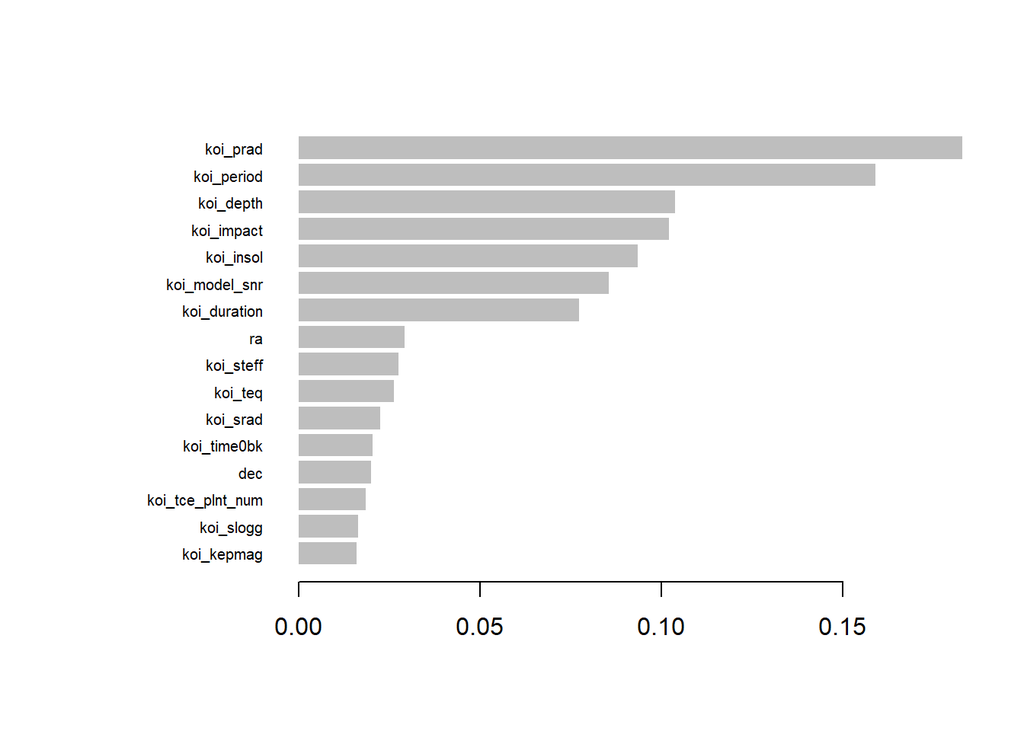

```r
xgb.plot.importance(xgb.importance(model = model_clas_xgbTree$finalModel))
```

**Random Forest**

Creamos un Random Forest, que combina muchos árboles de decisión para mejorar la predicción. Es útil porque reduce la varianza y suele dar mejores resultados que un solo árbol.

Se puede notar que prad es el atributo más importante.

```r
model_class_rf <- train(koi_pdisposition ~ ., kepler_classifier,
                        method="rf",
                        trControl=myControl_clas1,
                        tuneGrid = data.frame(mtry = c(1,3,5)),
                        ntree=50)
print(model_class_rf)
```

```
## Random Forest
##
## 8945 samples
##   16 predictor
##    2 classes: 'CANDIDATE', 'FALSE.POSITIVE'
##
## No pre-processing
## Resampling: Cross-Validated (10 fold)
## Summary of sample sizes: 8050, 8052, 8050, 8051, 8050, 8050, ...
## Resampling results across tuning parameters:
##
##   mtry  ROC        Sens       Spec
##   1     0.9084022  0.8439547  0.8235594
##   3     0.9169424  0.8400672  0.8447863
##   5     0.9176660  0.8414376  0.8443482
##
## ROC was used to select the optimal model using the largest value.
## The final value used for the model was mtry = 5.
```

Veamos los atributos del random forest en orden de importancia:

```r
varImp(model_class_rf)
```

```
## rf variable importance
##
##                  Overall
## koi_prad          100.00
## koi_period         53.82
## koi_depth          45.36
## koi_duration       43.67
## koi_impact         40.54
## koi_model_snr      38.30
## koi_insol          37.78
## koi_teq            34.84
## koi_time0bk        23.92
## ra                 20.60
## koi_steff          15.89
## koi_srad           14.94
## dec                14.31
## koi_slogg          13.62
## koi_kepmag         12.87
## koi_tce_plnt_num    0.00
```

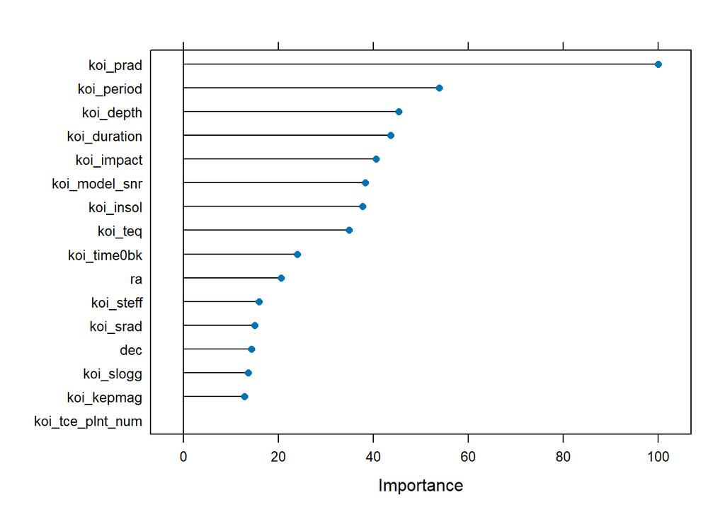

```r
plot(varImp(model_class_rf))
```

También podemos visualizar un rpart (Recursive Partitioning And Regression Tree):

[figure not shown]

```r
tree <- rpart(koi_pdisposition~., kepler_classifier, method = "class",
               control = rpart.control(cp=0.01))

fancyRpartPlot(tree)
```

Si bajamos el parámetro de complejidad cp, vemos que no se cambian mucho las ramas más importantes.

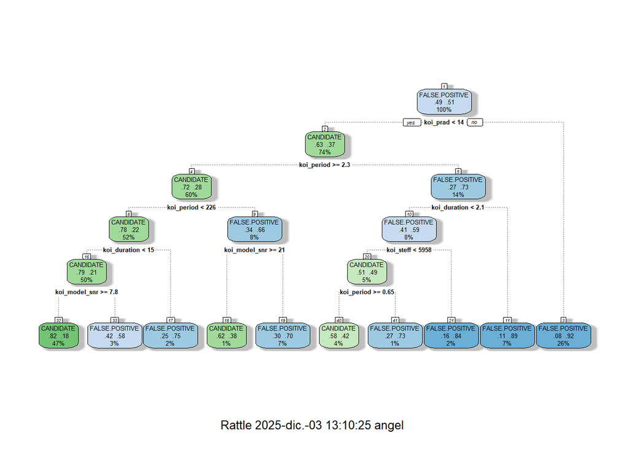

```r
tree_cp_small <- rpart(koi_pdisposition~., kepler_classifier, method = "class",
               control = rpart.control(cp=0.003))

fancyRpartPlot(tree_cp_small)
```

Igualmente, si usamos la información en vez del coeficiente gini para separar, las ramas no combian mucho:

[figure not shown]

```r
tree_i <- rpart(koi_pdisposition~., kepler_classifier, method = "class",
               control = rpart.control(cp=0.003), parms = list(split = "information"))

fancyRpartPlot(tree_i)
```

**KNN - k vecinos más cercanos**

Este modelo clasifica basándose en los ejemplos “más parecidos”. No suele ser el más potente en datasets con muchas variables o distintos rangos, pero es bueno tenerlo como base. Caret además calcula automáticamente el mejor valor de k según la validación cruzada.

```r
 model_knn <- train(
  koi_pdisposition ~ .,
  data = train_data,
  method = "knn",
  trControl = myControl_clas,
  metric = "ROC",
  tuneLength = 10
)
model_knn
```

```
## k-Nearest Neighbors
##
## 7157 samples
##   16 predictor
##    2 classes: 'CANDIDATE', 'FALSE.POSITIVE'
##
## No pre-processing
## Resampling: Cross-Validated (3 fold)
## Summary of sample sizes: 4770, 4772, 4772
## Resampling results across tuning parameters:
##
##   k   ROC        Sens       Spec
##    5  0.7894619  0.7612774  0.7072526
##    7  0.8039134  0.7729858  0.7113570
##    9  0.8102830  0.7824078  0.7099902
##   11  0.8129121  0.7918310  0.7113561
##   13  0.8161438  0.7944007  0.7149148
##   15  0.8186634  0.7961148  0.7124515
##   17  0.8212257  0.8003968  0.7124517
##   19  0.8219756  0.8003961  0.7099873
##   21  0.8218595  0.8021108  0.7077984
##   23  0.8230261  0.8006822  0.7165528
##
## ROC was used to select the optimal model using the largest value.
## The final value used for the model was k = 23.
```

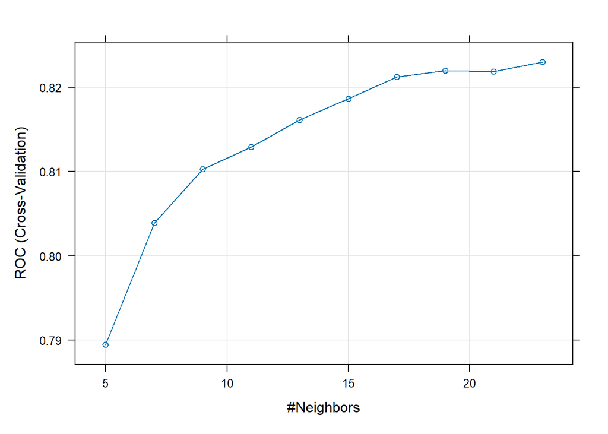

```r
plot(model_knn)
```

**Gradient Boosting (GBM)**

Probamos Gradient Boosting, que combina muchos árboles débiles de forma secuencial para mejorar la predicción. Suele funcionar muy bien en datasets medianos y ayuda a capturar relaciones complejas.

```r
model_gbm <- train(
koi_pdisposition ~ .,
data = train_data,
method = "gbm",
trControl = myControl_clas,
metric = "ROC",
verbose = FALSE,
tuneLength = 3
)
model_gbm
```

```
## Stochastic Gradient Boosting
##
## 7157 samples
##   16 predictor
##    2 classes: 'CANDIDATE', 'FALSE.POSITIVE'
##
## No pre-processing
## Resampling: Cross-Validated (3 fold)
## Summary of sample sizes: 4772, 4771, 4771
## Resampling results across tuning parameters:
##
##   interaction.depth  n.trees  ROC        Sens       Spec
##   1                   50      0.8762689  0.8683612  0.7203858
##   1                  100      0.8882134  0.8440898  0.7712738
##   1                  150      0.8923881  0.8449469  0.7813952
##   2                   50      0.8915051  0.8486565  0.7630666
##   2                  100      0.9014336  0.8466598  0.7975374
##   2                  150      0.9041288  0.8463746  0.8128588
##   3                   50      0.9011538  0.8423770  0.7912441
##   3                  100      0.9067467  0.8449465  0.8125847
##   3                  150      0.9081665  0.8460897  0.8164150
##
## Tuning parameter 'shrinkage' was held constant at a value of 0.1
##
## Tuning parameter 'n.minobsinnode' was held constant at a value of 10
## ROC was used to select the optimal model using the largest value.
## The final values used for the model were n.trees = 150, interaction.depth =
##  3, shrinkage = 0.1 and n.minobsinnode = 10.
```

**XGBoost**

Usamos XGBoost, un boosting muy eficiente y popular en competiciones. Es un poco más rápido que GBM y a veces da mejores resultados en datasets desequilibrados.

```r
model_xgb <- train(
koi_pdisposition ~ .,
data = train_data,
method = "xgbTree",
trControl = myControl_clas,
metric = "ROC",
tuneLength = 3
)
```

[output not shown]

[output cut: 377 more lines]

[output not shown]

```r
model_xgb
```

```
## eXtreme Gradient Boosting
##
## 7157 samples
##   16 predictor
##    2 classes: 'CANDIDATE', 'FALSE.POSITIVE'
##
## No pre-processing
## Resampling: Cross-Validated (3 fold)
## Summary of sample sizes: 4772, 4772, 4770
## Resampling results across tuning parameters:
##
##   eta  max_depth  colsample_bytree  subsample  nrounds  ROC        Sens
##   0.3  1          0.6               0.50        50      0.8927719  0.8512289
##   0.3  1          0.6               0.50       100      0.8974653  0.8463727
##   0.3  1          0.6               0.50       150      0.8980197  0.8443732
##   0.3  1          0.6               0.75        50      0.8909008  0.8543672
##   0.3  1          0.6               0.75       100      0.8966103  0.8478008
##   0.3  1          0.6               0.75       150      0.8980220  0.8460875
##   0.3  1          0.6               1.00        50      0.8907347  0.8563691
##   0.3  1          0.6               1.00       100      0.8965823  0.8515133
##   0.3  1          0.6               1.00       150      0.8974145  0.8520843
##   0.3  1          0.8               0.50        50      0.8911612  0.8535135
##   0.3  1          0.8               0.50       100      0.8969024  0.8469444
##   0.3  1          0.8               0.50       150      0.8968397  0.8406603
##   0.3  1          0.8               0.75        50      0.8914771  0.8529422
##   0.3  1          0.8               0.75       100      0.8983653  0.8526558
##   0.3  1          0.8               0.75       150      0.8985318  0.8492297
##   0.3  1          0.8               1.00        50      0.8908925  0.8560827
##   0.3  1          0.8               1.00       100      0.8965696  0.8520846
##   0.3  1          0.8               1.00       150      0.8976034  0.8526556
##   0.3  2          0.6               0.50        50      0.9040370  0.8463731
##   0.3  2          0.6               0.50       100      0.9068980  0.8463734
##   0.3  2          0.6               0.50       150      0.9070843  0.8420891
##   0.3  2          0.6               0.75        50      0.9069275  0.8440886
##   0.3  2          0.6               0.75       100      0.9101087  0.8446591
##   0.3  2          0.6               0.75       150      0.9116262  0.8489429
##   0.3  2          0.6               1.00        50      0.9058341  0.8432312
##   0.3  2          0.6               1.00       100      0.9102241  0.8477996
##   0.3  2          0.6               1.00       150      0.9121478  0.8480867
##   0.3  2          0.8               0.50        50      0.9056730  0.8472278
```

[output cut: 182 more lines]

```
##   0.8101246
##   0.8273599
##   0.8350189
##   0.8295470
##   0.8243522
##   0.8249004
##   0.8243531
##
## Tuning parameter 'gamma' was held constant at a value of 0
## Tuning
##  parameter 'min_child_weight' was held constant at a value of 1
## ROC was used to select the optimal model using the largest value.
## The final values used for the model were nrounds = 100, max_depth = 3, eta
##  = 0.3, gamma = 0, colsample_bytree = 0.8, min_child_weight = 1 and subsample
##  = 1.
```

**Naive Bayes**

Modelo muy simple que asume independencia entre variables. Aunque no suele ser el más preciso, es un buen baseline para comparar con modelos más complejos.

```r
model_nb <- train(
koi_pdisposition ~ .,
data = train_data,
method = "naive_bayes",
trControl = myControl_clas,
metric = "ROC",
tuneLength = 3
)
model_nb
```

```
## Naive Bayes
##
## 7157 samples
##   16 predictor
##    2 classes: 'CANDIDATE', 'FALSE.POSITIVE'
##
## No pre-processing
## Resampling: Cross-Validated (3 fold)
## Summary of sample sizes: 4770, 4772, 4772
## Resampling results across tuning parameters:
##
##   usekernel  ROC        Sens       Spec
##   FALSE      0.8159563  0.9731564  0.2971324
##    TRUE      0.8309483  0.9620267  0.3852095
##
## Tuning parameter 'laplace' was held constant at a value of 0
## Tuning
##  parameter 'adjust' was held constant at a value of 1
## ROC was used to select the optimal model using the largest value.
## The final values used for the model were laplace = 0, usekernel = TRUE
##  and adjust = 1.
```

Una vez entrenados los distintos modelos, juntamos todos en una lista y los comparamos usando la métrica ROC. De este modo podemos ver de un vistazo cuál obtiene mejor rendimiento medio a través de los folds de validación cruzada.

```r
model_list <- list(
  glm = model_glm,
  #glmnet = model_glmnet,
  #rf = model_class_rf,
  svm = model_svm,
  #rpart = model_clas_xgbTree,
  knn = model_knn,
  gbm = model_gbm,
  xgb = model_xgb,
  nb = model_nb
)

res <- resamples(model_list)
summary(res, metric="ROC")
```

```
##
## Call:
## summary.resamples(object = res, metric = "ROC")
##
## Models: glm, svm, knn, gbm, xgb, nb
## Number of resamples: 3
##
## ROC
##          Min.   1st Qu.    Median      Mean   3rd Qu.      Max. NA's
## glm 0.6517248 0.7510081 0.8502913 0.7863270 0.8536281 0.8569649    0
## svm 0.8727331 0.8755331 0.8783331 0.8786570 0.8816190 0.8849048    0
## knn 0.8209927 0.8215810 0.8221692 0.8230261 0.8240428 0.8259164    0
## gbm 0.8962169 0.9034266 0.9106363 0.9081665 0.9141413 0.9176463    0
## xgb 0.9083851 0.9117594 0.9151337 0.9147104 0.9178730 0.9206124    0
## nb  0.8198734 0.8264682 0.8330630 0.8309483 0.8364858 0.8399085    0
```

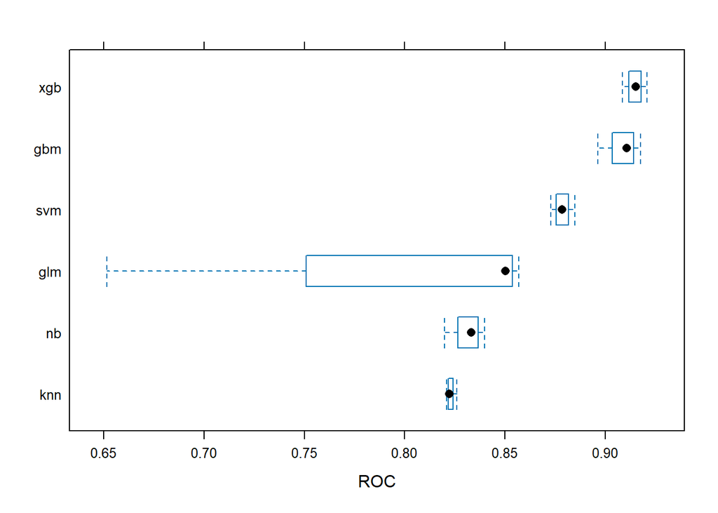

```r
bwplot(res, metric = "ROC")
```

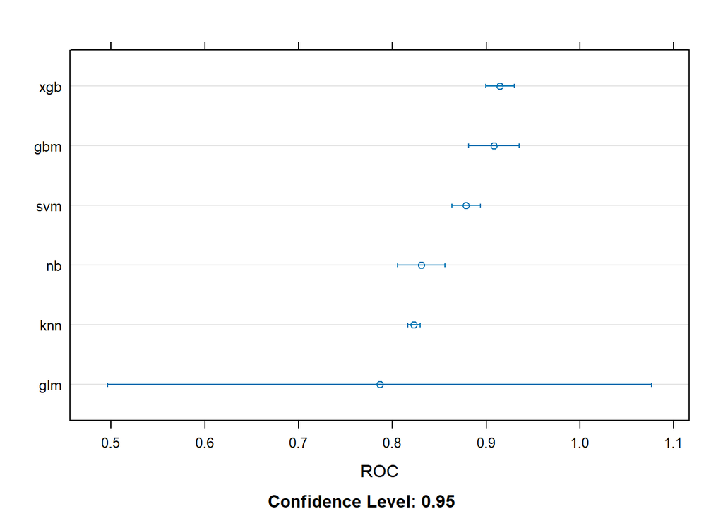

```r
dotplot(res, metric = "ROC")
```

Finalmente evaluamos los modelos (en este caso xgb) sobre el conjunto reservado a test para ver cómo actúa. Mediante la Matriz de Confusión vemos donde se ubican los mayores fallos, si en FALSE POSITIVE o en CANDIDATE

```r
pred <- predict(model_xgb, newdata = test_data)
confusionMatrix(pred, test_data$koi_pdisposition)
```

```
## Confusion Matrix and Statistics
##
##                 Reference
## Prediction       CANDIDATE FALSE.POSITIVE
##   CANDIDATE            757            147
##   FALSE.POSITIVE       118            766
##
##                Accuracy : 0.8518
##                  95% CI : (0.8345, 0.868)
##     No Information Rate : 0.5106
##     P-Value [Acc > NIR] : < 2e-16
##
##                   Kappa : 0.7036
##
##  Mcnemar's Test P-Value : 0.08543
##
##             Sensitivity : 0.8651
##             Specificity : 0.8390
##          Pos Pred Value : 0.8374
##          Neg Pred Value : 0.8665
##              Prevalence : 0.4894
##          Detection Rate : 0.4234
##    Detection Prevalence : 0.5056
##       Balanced Accuracy : 0.8521
##
##        'Positive' Class : CANDIDATE
##
```

## Aprendizaje no Supervisado

**K-means**

Como primer método de aprendizaje no supervisado hemos decidido aplicar el K-means. Para ello, hemos tenido que eliminar algunas columnas del dataset que no eran numéricas para poder llevar a cabo el método.

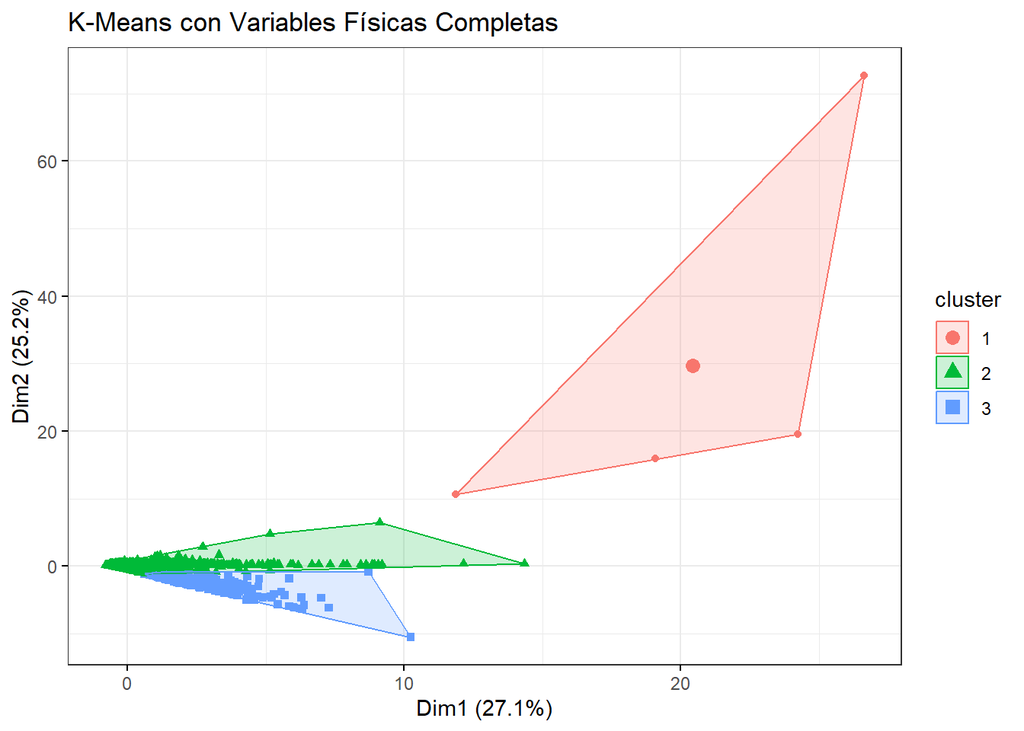

```r
library(tidyverse)

kep_nuevo <- kepler %>%
  select(koi_period,
         koi_duration,
         koi_depth,
         koi_prad)

# 2. Limpiamos los Nulos
kep_limpio <- na.omit(kep_nuevo)

# 3. Escalamos para evitar errores de escala entre los datos.
kep_escalado <- scale(kep_limpio)

# 4. Ejecutamos el algoritmo.
set.seed(123)
km_final <- kmeans(kep_escalado, centers = 3, nstart = 25)

# 5. Visualizamos el resultado del k-means.
fviz_cluster(km_final, data = kep_escalado, geom = "point",
             ellipse.type = "convex", ggtheme = theme_bw(),
             main = "K-Means con Variables Físicas Completas")
```